# Lab 1: Introduction to R and Descriptive Statistics

# Part 1: Getting Started with R

## R as a Calculator

At its most basic, R works just like a calculator. Try typing some commands:

```r
# Basic arithmetic
3 + 4
```

```
## [1] 7
```

```r
10 - 3
```

```
## [1] 7
```

```r
5 * 6
```

```
## [1] 30
```

```r
20 / 4
```

```
## [1] 5
```

```r
2^3  # exponentiation
```

```
## [1] 8
```

You can also use parentheses to control order of operations:

```r
(3 + 4) * 2
```

```
## [1] 14
```

```r
3 + 4 * 2  # different result!
```

```
## [1] 11
```

## Variables and Assignment

Variables let you store values and reuse them later. We create variables using the assignment operator `<-`:

```r
# Create a variable
x <- 5
x
```

```
## [1] 5
```

```r
# Create more variables
y <- 10
z <- x + y
z
```

```
## [1] 15
```

The `<-` operator says “take the value on the right and store it in the variable on the left.” You can also use `=` for assignment, but `<-` is more traditional in R.

```r
# You can update variables
x <- x + 1
x  # now equals 6
```

```
## [1] 6
```

## Functions

A function is an operator that takes some input and gives an output based on that input. Think of it like a (reusable) machine: you put something in, it processes it, and gives you a result.

### Basic Functions

For example, R has a function called `abs()` that calculates the absolute value:

```r
# Create a negative number
x <- -3

# Get its absolute value
abs(x)
```

```
## [1] 3
```

```r
# Try with other numbers
abs(-15.7)
```

```
## [1] 15.7
```

```r
abs(42)  # absolute value of positive number is itself
```

```
## [1] 42
```

Here are some other useful basic functions:

```r
# Square root
sqrt(16)
```

```
## [1] 4
```

```r
sqrt(25)
```

```
## [1] 5
```

```r
# Rounding
round(3.7)
```

```
## [1] 4
```

```r
round(3.14159, digits = 2)  # round to 2 decimal places
```

```
## [1] 3.14
```

```r
# Exponentiation (another way besides ^)
exp(1)  # e^1
```

```
## [1] 2.718282
```

```r
log(10)  # natural logarithm
```

```
## [1] 2.302585
```

### Function Arguments

Most functions take inputs called **arguments**. Some arguments are required, others are optional with default values.

Let’s look at the `round()` function more carefully:

```r
# Round to nearest integer (default)
round(3.14159)
```

```
## [1] 3
```

```r
# Specify number of decimal places
round(3.14159, digits = 2)
```

```
## [1] 3.14
```

```r
round(3.14159, digits = 4)
```

```
## [1] 3.1416
```

The `digits` argument is optional - if you don’t specify it, R uses a default value.

### Getting Help on Functions

You can look up any function’s documentation:

```r
# View help page
?round
help(round)

# See examples of how to use it
example(round)

# Search for functions related to a topic
# ??statistics
```

The help page tells you: - What the function does - What arguments it takes - Which arguments have default values - Examples of usage

### Functions with Multiple Arguments

Some functions have several arguments. For example, `seq()` creates sequences of numbers:

```r
# Create a sequence from 1 to 10
seq(from = 1, to = 10)
```

```
##  [1]  1  2  3  4  5  6  7  8  9 10
```

```r
# Every other number
seq(from = 1, to = 10, by = 2)
```

```
## [1] 1 3 5 7 9
```

```r
# Specify length instead of increment
seq(from = 0, to = 1, length.out = 5)
```

```
## [1] 0.00 0.25 0.50 0.75 1.00
```

### Variable Naming Best Practices

When creating variables, use descriptive names:

```r
# Bad: unclear what these represent
x <- 25000
y <- 0.05

# Good: clear and descriptive
salary <- 25000
tax_rate <- 0.05
tax_amount <- salary * tax_rate
tax_amount
```

```
## [1] 1250
```

Good variable names: - Use lowercase letters - Separate words with underscores: `my_variable` - Are descriptive: `student_height` not just `h` - Avoid special characters except underscore - Don’t start with numbers

## Types of Data

R has several basic data types:

```r
# Numeric (real numbers)
height <- 170.5
weight <- 68.3

# Integer (whole numbers)
age <- 25
n_siblings <- 2

# Character (text strings)
name <- "Alice"
favorite_food <- "pizza"

# Logical (TRUE or FALSE)
is_student <- TRUE
has_passed <- FALSE
```

You can check what type something is:

```r
class(height)
```

```
## [1] "numeric"
```

```r
class(name)
```

```
## [1] "character"
```

```r
class(is_student)
```

```
## [1] "logical"
```

## Logical Operators

Logical operators let you compare values and get TRUE/FALSE answers:

```r
# Comparisons
5 > 3
```

```
## [1] TRUE
```

```r
10 < 8
```

```
## [1] FALSE
```

```r
7 == 7  # equals (note: two equal signs!)
```

```
## [1] TRUE
```

```r
5 != 3  # not equal
```

```
## [1] TRUE
```

```r
# With variables
x <- 10
y <- 15
x < y
```

```
## [1] TRUE
```

```r
x == y
```

```
## [1] FALSE
```

# Part 2: Vectors

## Creating Vectors

Most data in R is stored in vectors - collections of values of the same type. Create vectors with the `c()` function (c stands for “combine” or “concatenate”):

```r
# Create a numeric vector
exam_scores <- c(85, 92, 78, 95, 88, 76, 90)
exam_scores
```

```
## [1] 85 92 78 95 88 76 90
```

```r
# Create a character vector
student_names <- c("Alice", "Bob", "Carol", "David", "Eve")
student_names
```

```
## [1] "Alice" "Bob"   "Carol" "David" "Eve"
```

```r
# Create a logical vector
passed_exam <- c(TRUE, TRUE, FALSE, TRUE, TRUE, TRUE, FALSE)
passed_exam
```

```
## [1]  TRUE  TRUE FALSE  TRUE  TRUE  TRUE FALSE
```

## Accessing Vector Elements

You can access individual elements or ranges using square brackets `[]`. **Important:** R starts counting at 1, not 0!

```r
# Get the first score
exam_scores[1]
```

```
## [1] 85
```

```r
# Get the third score
exam_scores[3]
```

```
## [1] 78
```

```r
# Get multiple scores (positions 2 through 4)
exam_scores[2:4]
```

```
## [1] 92 78 95
```

```r
# Get specific positions
exam_scores[c(1, 3, 5)]
```

```
## [1] 85 78 88
```

You can also modify specific elements:

```r
# Change the third score
exam_scores[3] <- 80
exam_scores
```

```
## [1] 85 92 80 95 88 76 90
```

## Vector Operations

Mathematical operations work on entire vectors:

```r
# Add 5 points to everyone's score
exam_scores + 5
```

```
## [1]  90  97  85 100  93  81  95
```

```r
# Multiply all scores by 1.1 (10% bonus)
exam_scores * 1.1
```

```
## [1]  93.5 101.2  88.0 104.5  96.8  83.6  99.0
```

```r
# Operations between vectors (element-wise)
quiz1 <- c(8, 9, 7, 10, 6)
quiz2 <- c(7, 8, 9, 9, 8)
total_quiz_score <- quiz1 + quiz2
total_quiz_score
```

```
## [1] 15 17 16 19 14
```

## Useful Vector Functions

R has many built-in functions for working with vectors:

```r
scores <- c(85, 92, 78, 95, 88, 76, 90)

# How many elements?
length(scores)
```

```
## [1] 7
```

```r
# Sum of all values
sum(scores)
```

```
## [1] 604
```

```r
# Minimum and maximum
min(scores)
```

```
## [1] 76
```

```r
max(scores)
```

```
## [1] 95
```

```r
# Sort the values
sort(scores)
```

```
## [1] 76 78 85 88 90 92 95
```

```r
# Get a statistical summary
summary(scores)
```

```
##    Min. 1st Qu.  Median    Mean 3rd Qu.    Max.
##   76.00   81.50   88.00   86.29   91.00   95.00
```

# Part 3: Data Frames

## What is a Data Frame?

A data frame is like a spreadsheet - it has rows (observations) and columns (variables). Each column can be a different type of data.

## Creating a Data Frame

Let’s create a small dataset about students:

```r
# Create individual vectors
student_id <- c(1, 2, 3, 4, 5)
student_name <- c("Alice", "Bob", "Carol", "David", "Eve")
age <- c(20, 22, 21, 23, 20)
exam_score <- c(85, 92, 78, 95, 88)
passed <- c(TRUE, TRUE, TRUE, TRUE, TRUE)

# Combine into a data frame
students <- data.frame(
  id = student_id,
  name = student_name,
  age = age,
  score = exam_score,
  passed = passed
)

# View the data frame
students
```

```
##   id  name age score passed
## 1  1 Alice  20    85   TRUE
## 2  2   Bob  22    92   TRUE
## 3  3 Carol  21    78   TRUE
## 4  4 David  23    95   TRUE
## 5  5   Eve  20    88   TRUE
```

## Exploring Data Frames

```r
# Get dimensions (rows, columns)
dim(students)
```

```
## [1] 5 5
```

```r
nrow(students)
```

```
## [1] 5
```

```r
ncol(students)
```

```
## [1] 5
```

```r
# Get column names
names(students)
```

```
## [1] "id"     "name"   "age"    "score"  "passed"
```

```r
# See first few rows
head(students)
```

```
##   id  name age score passed
## 1  1 Alice  20    85   TRUE
## 2  2   Bob  22    92   TRUE
## 3  3 Carol  21    78   TRUE
## 4  4 David  23    95   TRUE
## 5  5   Eve  20    88   TRUE
```

## Accessing Data Frame Columns

There are several ways to access columns:

```r
# Using $ operator (most common)
students$score
```

```
## [1] 85 92 78 95 88
```

```r
# Using column name in brackets
students[, "score"]
```

```
## [1] 85 92 78 95 88
```

```r
# Using column number
students[, 4]
```

```
## [1] 85 92 78 95 88
```

You can also access specific cells:

```r
# Row 3, column 4
students[3, 4]
```

```
## [1] 78
```

```r
# All of row 2
students[2, ]
```

```
##   id name age score passed
## 2  2  Bob  22    92   TRUE
```

```r
# All of column "age"
students[, "age"]
```

```
## [1] 20 22 21 23 20
```

# Part 4: Loading Real Data

## Installing and Loading Packages

R’s functionality is extended through packages. Let’s install and load the NHANES dataset:

```r
# Run this once to install (then you can comment it out)
# install.packages("NHANES")
```

```r
# Load package for this session
library(NHANES)
```

## The NHANES Dataset

NHANES is the National Health and Nutrition Examination Survey - a major US health survey. Let’s load and explore it:

```r
# Load the data
data(NHANES)

# Look at the structure
str(NHANES)
```

```
## Classes 'tbl_df', 'tbl' and 'data.frame':    10000 obs. of  76 variables:
##  $ ID              : int  51624 51624 51624 51625 51630 51638 51646 51647 51647 51647 ...
##  $ SurveyYr        : Factor w/ 2 levels "2009_10","2011_12": 1 1 1 1 1 1 1 1 1 1 ...
##  $ Gender          : Factor w/ 2 levels "female","male": 2 2 2 2 1 2 2 1 1 1 ...
##  $ Age             : int  34 34 34 4 49 9 8 45 45 45 ...
##  $ AgeDecade       : Factor w/ 8 levels " 0-9"," 10-19",..: 4 4 4 1 5 1 1 5 5 5 ...
##  $ AgeMonths       : int  409 409 409 49 596 115 101 541 541 541 ...
##  $ Race1           : Factor w/ 5 levels "Black","Hispanic",..: 4 4 4 5 4 4 4 4 4 4 ...
##  $ Race3           : Factor w/ 6 levels "Asian","Black",..: NA NA NA NA NA NA NA NA NA NA ...
##  $ Education       : Factor w/ 5 levels "8th Grade","9 - 11th Grade",..: 3 3 3 NA 4 NA NA 5 5 5 ...
##  $ MaritalStatus   : Factor w/ 6 levels "Divorced","LivePartner",..: 3 3 3 NA 2 NA NA 3 3 3 ...
##  $ HHIncome        : Factor w/ 12 levels " 0-4999"," 5000-9999",..: 6 6 6 5 7 11 9 11 11 11 ...
##  $ HHIncomeMid     : int  30000 30000 30000 22500 40000 87500 60000 87500 87500 87500 ...
##  $ Poverty         : num  1.36 1.36 1.36 1.07 1.91 1.84 2.33 5 5 5 ...
##  $ HomeRooms       : int  6 6 6 9 5 6 7 6 6 6 ...
```

[output cut: 62 more lines]

```r
# How big is it?
dim(NHANES)
```

```
## [1] 10000    76
```

```r
# What variables do we have?
names(NHANES)
```

```
##  [1] "ID"               "SurveyYr"         "Gender"           "Age"
##  [5] "AgeDecade"        "AgeMonths"        "Race1"            "Race3"
##  [9] "Education"        "MaritalStatus"    "HHIncome"         "HHIncomeMid"
## [13] "Poverty"          "HomeRooms"        "HomeOwn"          "Work"
## [17] "Weight"           "Length"           "HeadCirc"         "Height"
## [21] "BMI"              "BMICatUnder20yrs" "BMI_WHO"          "Pulse"
## [25] "BPSysAve"         "BPDiaAve"         "BPSys1"           "BPDia1"
## [29] "BPSys2"           "BPDia2"           "BPSys3"           "BPDia3"
## [33] "Testosterone"     "DirectChol"       "TotChol"          "UrineVol1"
## [37] "UrineFlow1"       "UrineVol2"        "UrineFlow2"       "Diabetes"
## [41] "DiabetesAge"      "HealthGen"        "DaysPhysHlthBad"  "DaysMentHlthBad"
## [45] "LittleInterest"   "Depressed"        "nPregnancies"     "nBabies"
## [49] "Age1stBaby"       "SleepHrsNight"    "SleepTrouble"     "PhysActive"
## [53] "PhysActiveDays"   "TVHrsDay"         "CompHrsDay"       "TVHrsDayChild"
## [57] "CompHrsDayChild"  "Alcohol12PlusYr"  "AlcoholDay"       "AlcoholYear"
## [61] "SmokeNow"         "Smoke100"         "Smoke100n"        "SmokeAge"
## [65] "Marijuana"        "AgeFirstMarij"    "RegularMarij"     "AgeRegMarij"
## [69] "HardDrugs"        "SexEver"          "SexAge"           "SexNumPartnLife"
## [73] "SexNumPartYear"   "SameSex"          "SexOrientation"   "PregnantNow"
```

That’s a lot of data! Let’s look at just the first few rows:

```r
head(NHANES)
```

```
##      ID SurveyYr Gender Age AgeDecade AgeMonths Race1 Race3    Education
## 1 51624  2009_10   male  34     30-39       409 White  <NA>  High School
## 2 51624  2009_10   male  34     30-39       409 White  <NA>  High School
## 3 51624  2009_10   male  34     30-39       409 White  <NA>  High School
## 4 51625  2009_10   male   4       0-9        49 Other  <NA>         <NA>
## 5 51630  2009_10 female  49     40-49       596 White  <NA> Some College
## 6 51638  2009_10   male   9       0-9       115 White  <NA>         <NA>
##   MaritalStatus    HHIncome HHIncomeMid Poverty HomeRooms HomeOwn       Work
## 1       Married 25000-34999       30000    1.36         6     Own NotWorking
## 2       Married 25000-34999       30000    1.36         6     Own NotWorking
## 3       Married 25000-34999       30000    1.36         6     Own NotWorking
## 4          <NA> 20000-24999       22500    1.07         9     Own       <NA>
## 5   LivePartner 35000-44999       40000    1.91         5    Rent NotWorking
## 6          <NA> 75000-99999       87500    1.84         6    Rent       <NA>
##   Weight Length HeadCirc Height   BMI BMICatUnder20yrs   BMI_WHO Pulse BPSysAve
```

[output cut: 62 more lines]

# Part 5: Descriptive Statistics

## Why Do We Need Descriptive Statistics?

Imagine you have the heights of 1000 people. If you print all 1000 numbers, you won’t be able to make sense of them. Descriptive statistics summarize data so we can understand it.

Let’s work with a manageable example first:

```r
# Heights of 10 people (in cm)
heights <- c(165, 170, 168, 175, 172, 169, 180, 171, 166, 173)
heights
```

```
##  [1] 165 170 168 175 172 169 180 171 166 173
```

Just looking at these numbers, can you quickly tell what the typical height is? Not easily! That’s why we need summary statistics.

## Measures of Central Tendency

Central tendency tells us about the “center” or “typical value” of our data.

### The Mean

The mean is the arithmetic average: add everything up and divide by how many values you have.

**Formula:** $\bar{X} = \frac{1}{N}\sum_{i=1}^{N} X_i$

Let’s break down this notation: - $\bar{X}$ (X-bar) = the mean - $N$ = number of observations - $X_i$ = the i-th observation - $\sum$ (sigma) = sum (add up all the values)

```r
# Manual calculation
sum(heights) / length(heights)
```

```
## [1] 170.9
```

```r
# Using the built-in function
mean(heights)
```

```
## [1] 170.9
```

The mean is 170.9 cm. This tells us the “center of gravity” of our data.

**When to use the mean:** - Your data is roughly symmetric (no extreme outliers) - You want to use all the information in your data - You’re interested in the total or expected value

### The Median

The median is the middle value when you sort the data. Half the values are below it, half are above it.

```r
# Let's sort the heights to see the median visually
sort(heights)
```

```
##  [1] 165 166 168 169 170 171 172 173 175 180
```

```r
# The middle value (or average of two middle values if even number)
median(heights)
```

```
## [1] 170.5
```

The median is 170.5 cm. Notice it’s very close to the mean for this data.

**When to use the median:** - Your data has outliers or is skewed - You want to know the “typical” value - Your data is ordinal (ranked but not truly numeric)

### Mean vs. Median: A Concrete Example

Let’s see why this distinction matters:

```r
# Incomes of 5 people at a table
incomes <- c(50000, 55000, 60000, 65000, 70000)
mean(incomes)
```

```
## [1] 60000
```

```r
median(incomes)
```

```
## [1] 60000
```

Pretty similar! But now Bill Gates sits down:

```r
# Add Bill Gates's income (estimated $100 million/year)
incomes_with_gates <- c(50000, 55000, 60000, 65000, 70000, 100000000)
mean(incomes_with_gates)
```

```
## [1] 16716667
```

```r
median(incomes_with_gates)
```

```
## [1] 62500
```

The mean jumped to over $16 million! But the median only went up to $62,500. Which better represents the “typical” income at the table? The median, definitely.

**Key point:** The mean is pulled by extreme values. The median is resistant to them.

### The Mode

The mode is the most frequently occurring value.

```r
# Create a custom mode function (R doesn't have a built-in one)
get_mode <- function(x) {
  # Count frequencies
  freq_table <- table(x)

  # Find value(s) with highest frequency
  max_freq <- max(freq_table)
  modes <- names(freq_table[freq_table == max_freq])

  return(modes)
}

# Example: favorite colors in a class
colors <- c("blue", "red", "blue", "green", "blue", "red", "yellow", "blue")
get_mode(colors)
```

```
## [1] "blue"
```

```r
# The mode is "blue" - it appears most often
table(colors)
```

```
## colors
##   blue  green    red yellow
##      4      1      2      1
```

## Real Data Example: Heights in NHANES

Let’s apply these concepts to real data:

```r
# Remove duplicate participants (keep only unique IDs)
NHANES_clean <- NHANES[!duplicated(NHANES$ID), ]

# Create an adults-only dataset
NHANES_adults <- NHANES_clean[NHANES_clean$Age >= 18, ]

# Get heights for adults, removing missing values
adult_heights <- na.omit(NHANES_adults$Height)

# How many heights do we have?
length(adult_heights)
```

```
## [1] 4790
```

```r
# Calculate central tendency measures
mean(adult_heights)
```

```
## [1] 168.3497
```

```r
median(adult_heights)
```

```
## [1] 168.2
```

The mean and median are very close, suggesting the height distribution is fairly symmetric.

Let’s visualize this:

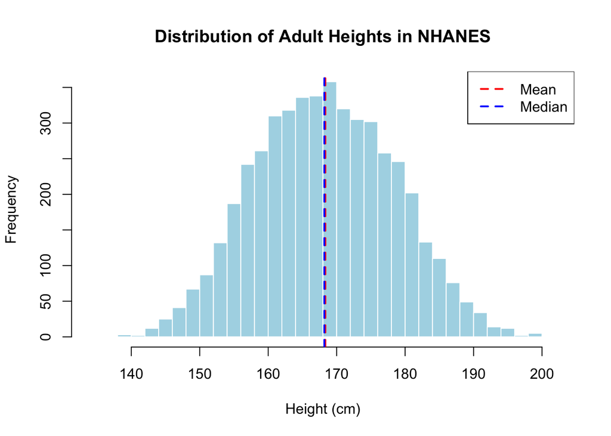

```r
# Create a histogram
hist(adult_heights,
     breaks = 30,
     main = "Distribution of Adult Heights in NHANES",
     xlab = "Height (cm)",
     col = "lightblue",
     border = "white")

# Add lines for mean and median
abline(v = mean(adult_heights), col = "red", lwd = 2, lty = 2)
abline(v = median(adult_heights), col = "blue", lwd = 2, lty = 2)
legend("topright",
       legend = c("Mean", "Median"),
       col = c("red", "blue"),
       lty = 2, lwd = 2)
```

## Handling Missing Data

Real data often has missing values (NA):

```r
# Some heights are missing in the full dataset
mean(NHANES_adults$Height)  # Returns NA
```

```
## [1] NA
```

```r
# Tell R to remove NAs
mean(NHANES_adults$Height, na.rm = TRUE)
```

```
## [1] 168.3497
```

Always use `na.rm = TRUE` when you have missing data!

## Comparing Groups

Let’s compare heights between males and females:

```r
# Get heights for males and females (removing NAs)
male_heights <- na.omit(NHANES_adults$Height[NHANES_adults$Gender == "male"])
female_heights <- na.omit(NHANES_adults$Height[NHANES_adults$Gender == "female"])

# Calculate means for each group
mean(male_heights)
```

```
## [1] 175.4343
```

```r
mean(female_heights)
```

```
## [1] 161.6114
```

```r
# Calculate medians
median(male_heights)
```

```
## [1] 175.4
```

```r
median(female_heights)
```

```
## [1] 161.7
```

```r
# How many in each group?
length(male_heights)
```

```
## [1] 2335
```

```r
length(female_heights)
```

```
## [1] 2455
```

On average, males are about 13 cm taller than females in this dataset.

# Part 6: Practice Exercises

Work through these on your own:

## Exercise 1: Basic Calculations

Calculate the mean and median of these test scores:

```r
test_scores <- c(67, 89, 75, 92, 88, 71, 95, 83, 78, 90)

# Your code here:
```

## Exercise 2: The Outlier Effect

1. Calculate the mean of these reaction times (in milliseconds):

```r
reaction_times <- c(245, 252, 238, 249, 241, 255, 247)

# Your code here:
```

2. Someone fell asleep and had a reaction time of 5000 ms. Add this to the data and recalculate the mean. How much did it change?

```r
# Your code here:
```

## Exercise 3: Creating Your Own Dataset

Create a data frame with at least 5 students containing: - Student name - Age - Test score - Passed (TRUE/FALSE)

Then calculate the mean test score and count how many passed.

```r
# Your code here:
```

# Resources and Help

## Getting Help in R

```r
# View help for a function
?mean
help(mean)

# Search for functions related to a topic
??regression

# See examples
example(mean)
```

## Common Error Messages

- `Error: object 'x' not found` → You haven’t created the variable yet
- `Error in ... : could not find function` → Package not loaded or typo
- `NA` result → Missing data; use `na.rm = TRUE`
- `Error: unexpected symbol` → Check your syntax (missing comma, parenthesis, etc.)

## Tips for Success

1. **Run code frequently** - Don’t write 20 lines before testing
2. **Read error messages** - They often tell you exactly what’s wrong
3. **Google is your friend** - Someone else has had your problem before
4. **Comment your code** - Use `#` to explain what you’re doing
5. **Practice, practice, practice** - Programming is a skill that improves with use

# Summary

Today you learned:

✓ How to use R as a calculator and create variables  
✓ Working with vectors and data frames  
✓ Loading and exploring real datasets  
✓ Three measures of central tendency: mean, median, and mode  
✓ When to use each measure  
✓ How to handle missing data

Next lab, we’ll cover measures of variability (standard deviation, variance, IQR) and fun data visualization techniques!